# Lista-09

Panosso, AR

17-12-2024

## Roteiro para análise diagnóstico

### Carregando Pacotes

```r
library(tidyverse)
library(agricolae)
library(ExpDes.pt) # <- ANOVA em português
library(nortest)
library(lawstat)
library(MASS)
library(HH) # <- teste de homogeneidade de variâncias
source("../r/minhas-funcoes.R")
theme_set(theme_bw()) # setar o tema padrão para o ggplot
```

### Entrada de Dados

```r
url <- "https://raw.githubusercontent.com/arpanosso/r-disciplina-pos/refs/heads/master/data/inseticidas.txt"
data_set <- read.table(url,header = TRUE) |>
  janitor::clean_names()
glimpse(data_set)
```

```
## Rows: 28
## Columns: 3
## $ trat <int> 1, 1, 1, 1, 2, 2, 2, 2, 3, 3, 3, 3, 4, 4, 4, 4, 5, 5, 5, 5, 6, 6,…
## $ bl   <int> 1, 2, 3, 4, 1, 2, 3, 4, 1, 2, 3, 4, 1, 2, 3, 4, 1, 2, 3, 4, 1, 2,…
## $ y    <dbl> 1469.14, 1475.31, 1067.90, 1160.49, 1462.96, 1512.35, 1203.70, 11…
```

### Estatística para os Tratamentos

Estatísticas resumos por tratamento, gráficos histograma, boxplot e qqnorm.

#### Estatística Descritiva

```r
data_set |>
  group_by(trat) |>
  summarise(
    n = n(),
    media = mean(y ,na.rm = TRUE),
    desv_pad = sd(y ,na.rm = TRUE),
    erro_pad = desv_pad/sqrt(n)
  )
```

```
## # A tibble: 7 × 5
##    trat     n media desv_pad erro_pad
##   <int> <int> <dbl>    <dbl>    <dbl>
## 1     1     4 1293.     210.    105.
## 2     2     4 1338.     174.     87.2
## 3     3     4 1231.     129.     64.6
## 4     4     4 1261.     162.     80.9
## 5     5     4 1196.     218.    109.
## 6     6     4  901.     226.    113.
## 7     7     4  978.     115.     57.7
```

#### Histograma da variável resposta

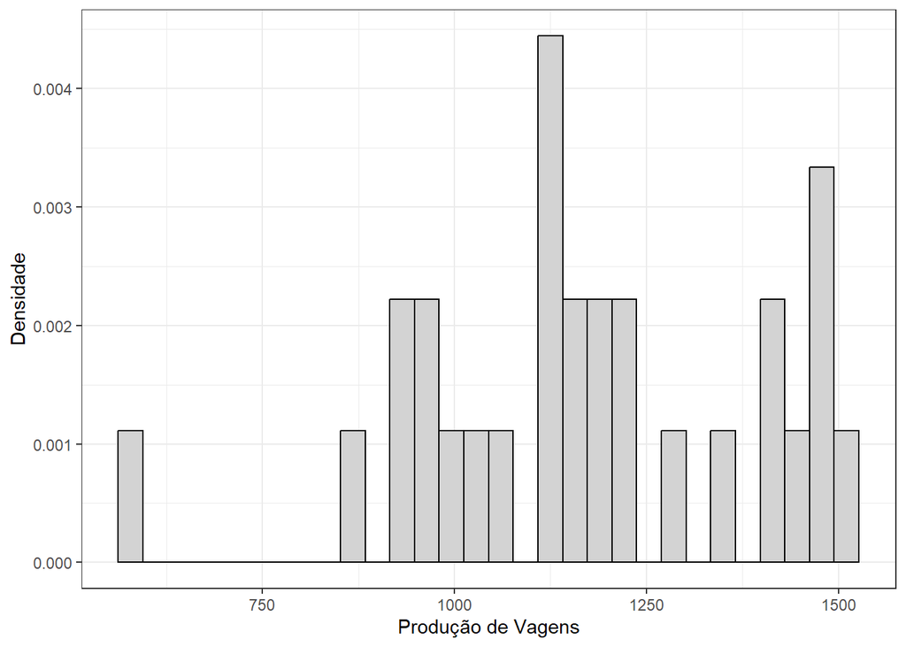

```r
data_set |>
  ggplot(aes(x=y , y=..density..)) +
  geom_histogram(color="black", fill="lightgray") +
  labs(y = "Densidade", x = "Produção de Vagens")
```

#### Gráfico Boxplot

Criar o boxplot ordenados por valor de média da variável alvo.

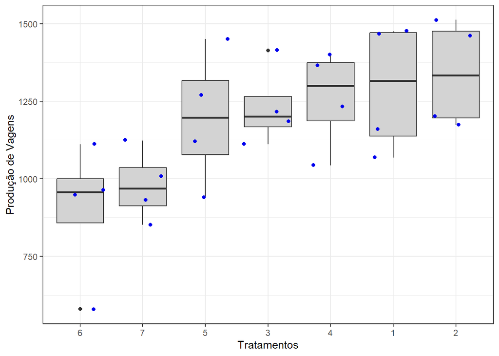

```r
data_set |>
  group_by(trat) |>
  mutate(
    media = mean(y, na.rm = TRUE),
    ) |>
  ungroup() |>
  mutate(
    trat = trat |> as_factor() |> fct_reorder(media)
  ) |>
  ggplot(aes(x=trat, y=y )) +
  geom_boxplot(fill="lightgray") +
  geom_jitter(color="blue2") +
  labs(x="Tratamentos", y="Produção de Vagens")
```

#### QQ-plot

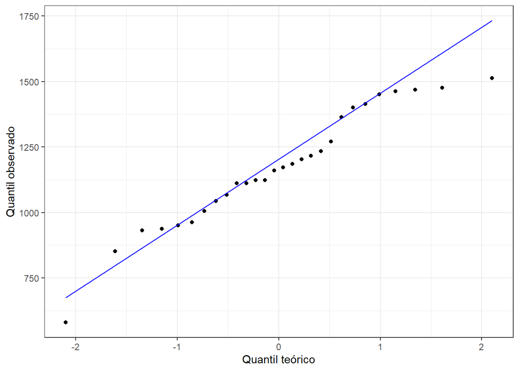

```r
data_set |>
  ggplot(aes(sample = y)) +
  stat_qq() +
  stat_qq_line(color = "blue") +
  labs(x="Quantil teórico", y="Quantil observado")
```

### Extração das colunas para realizar a análise de variância.

Para realizar a construção do modelo para ANOVA deve-se extrair todas as colunas envolvidas na definição do modelo da mesma.

```r
y <- data_set |> pull(y)
trat <- data_set |>  pull(trat) |> as_factor()
bloco <- data_set |>  pull(bl) |> as_factor()
is.factor(trat) # verificando se trat é fator
```

```
## [1] TRUE
```

```r
is.factor(bloco) # verificando se bloco é fator
```

```
## [1] TRUE
```

```r
is.numeric(y) # verificando se y é numérico
```

```
## [1] TRUE
```

### Definição do modelo

$$y_{ij} = \mu + \tau_i + \beta_j +
\epsilon_{ij}$$

Para analisar as pressuposições (Normalidade dos erros e Homocedasticidade), precisamos dos erros, desvios do modelo portanto, utilizamos a função `aov` - para construir o modelo da análise de variância. O resumo da análise com o quadro da ANOVA pode ser acessado com a função `anova`.

```r
# Substituição do outlier
# y <- ifelse(y == outlier, new_value, y)

# Definir o modelo
mod <- aov(y~trat + bloco)
anova(mod)
```

```
## Analysis of Variance Table
##
## Response: y
##           Df Sum Sq Mean Sq F value    Pr(>F)
## trat       6 660112  110019  6.4326 0.0009345 ***
## bloco      3 379967  126656  7.4053 0.0019620 **
## Residuals 18 307860   17103
## ---
## Signif. codes:  0 '***' 0.001 '**' 0.01 '*' 0.05 '.' 0.1 ' ' 1
```

### Normalidade dos resíduos

Uma vez o modelo salvo, precisamos extrair os resíduos, erros, para testar as pressuposições, estudar os outliers e definir possíveis transformações aos dados.

#### Extrair os resíduos e valores preditos

```r
rs <- rstudent(mod)
yp <- predict(mod)
```

#### Definir o data.frame contendo as colunas extraídas, os resíduos e valores preditos

```r
diagnostico <- data.frame(trat, y, yp, rs)
glimpse(diagnostico)
```

```
## Rows: 28
## Columns: 4
## $ trat <fct> 1, 1, 1, 1, 2, 2, 2, 2, 3, 3, 3, 3, 4, 4, 4, 4, 5, 5, 5, 5, 6, 6,…
## $ y    <dbl> 1469.14, 1475.31, 1067.90, 1160.49, 1462.96, 1512.35, 1203.70, 11…
## $ yp   <dbl> 1334.4350, 1449.0750, 1261.2436, 1128.0864, 1379.1875, 1493.8275,…
## $ rs   <dbl> 1.309954e+00, 2.435724e-01, -1.989658e+00, 3.011193e-01, 7.905545…
```

#### Histograma

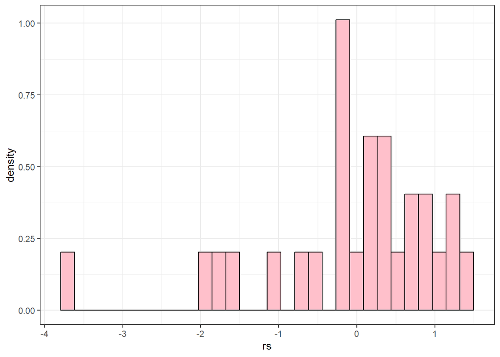

```r
diagnostico |>
  ggplot(aes(x=rs, y=..density..)) +
  geom_histogram(color="black",fill="pink")
```

#### QQ-plot

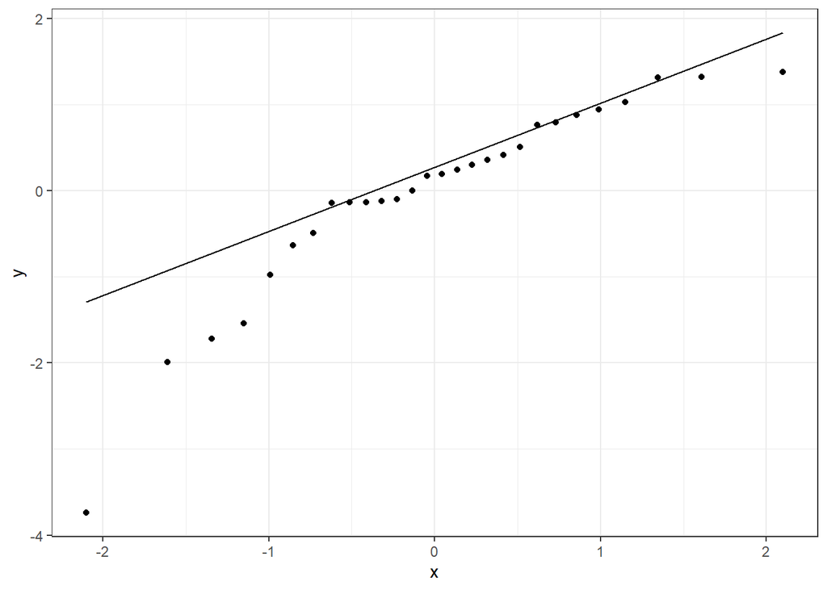

```r
diagnostico |>
  ggplot(aes(sample = rs)) +
  stat_qq()+
  stat_qq_line()
```

#### Teste de normalidade

Testando a normalidade dos resíduos e realizando a análise gráfica dos mesmos `install.packages("nortest")` caso necessário. Considere o alpha de 0,01.

```r
# Shapiro-Wilks
shapiro.test(rs)
```

```
##
##  Shapiro-Wilk normality test
##
## data:  rs
## W = 0.88088, p-value = 0.004198
```

```r
# Kolmogorov-Smirnov
lillie.test(rs)
```

```
##
##  Lilliefors (Kolmogorov-Smirnov) normality test
##
## data:  rs
## D = 0.21403, p-value = 0.002013
```

```r
# Anderson-Darlin
ad.test(rs)
```

```
##
##  Anderson-Darling normality test
##
## data:  rs
## A = 0.96042, p-value = 0.01312
```

```r
# Cramer-von Mises
cvm.test(rs)
```

```
##
##  Cramer-von Mises normality test
##
## data:  rs
## W = 0.16383, p-value = 0.01437
```

### Estudo de outliers

Os Resíduos brutos são aqueles calculados diretamente a partir do modelo da análise de variância definido, e podem ser acessados com a função `residual``.

Resíduos Padronizados (são os resíduo brutos dividido pelo erro padrão da estimativa dos resíduos). Se os erros têm distribuição normal, então aproximadamente 95% dos resíduos padronizados devem estar no intervalo de (-2,2). Resíduos fora desse intervalo podem indicar a presença de outliers. Utilize a função `rstandard` para calcular esses resíduos.

Resíduos Studentizados são considerados independentes pelo fato de serem resíduos decorrentes de procedimento leave-one-out. Para todos os efeitos, é como se o resíduo padronizado da observação i fosse calculado removendo-se o i-ésimo registro e ajustado o modelo. vantagem é que esses resíduos tem variância constante, (Var(rs) = 1) tornando muito mais fácil a procupra de outliers, ou seja, observações distantes das demais.

Para ilustrar qual resíduo utilizar na análise de resíduos, representar graficamente este gráfico usando os três resíduos, numa mesma figura e observar o que acontece.

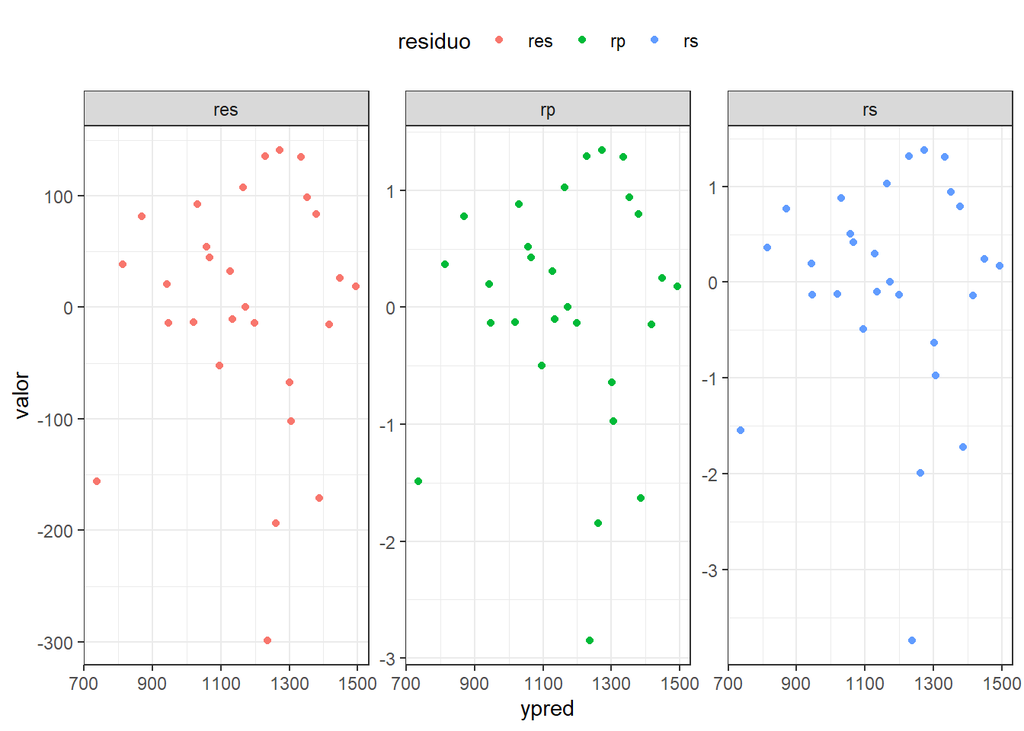

```r
res <- residuals(mod)
rp <- rstandard(mod)
rs <- rstudent(mod)
ypred <- predict(mod)

data.frame(res,rp,rs,ypred) |>
  pivot_longer(res:rs,names_to = "residuo", values_to = "valor") |>
  ggplot(aes(x=ypred, y=valor, color = residuo)) +
  geom_point() +
  facet_wrap(~residuo, scale = "free") +
  theme(
    legend.position = "top"
  )
```

#### Construir o gráfico dos resíduos studentizados vs valores preditos

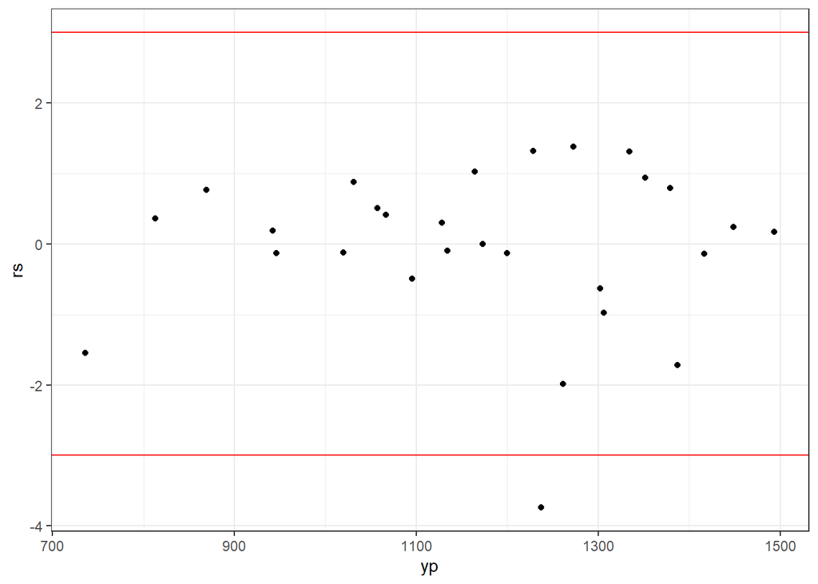

```r
diagnostico |>
  ggplot(aes(x=yp, y=rs)) +
  geom_point() +
  geom_hline(yintercept = c(3,-3), color = "red")
```

```r
diagnostico |>
  arrange(rs) |> slice(1) |> pull(y) -> outlier

diagnostico |>
  arrange(rs) |> slice(1) |> pull(yp) -> new_value
```

### Homogeneidade das variâncias (homocedasticidade)

Quatro testes podem ser empregados, o teste de Levene, o teste de Brown-Forsythe o teste de Bartlett e Box-Cox. Considere o alpha igual a 0,05.

#### Testes de homocedasticidade

```r
# Teste clássico de Levene
levene.test(y,trat,location="mean")
```

```
##
##  Classical Levene's test based on the absolute deviations from the mean
##  ( none not applied because the location is not set to median )
##
## data:  y
## Test Statistic = 0.84378, p-value = 0.5506
```

```r
# Teste Brown-Forsythe
levene.test(y,trat)
```

```
##
##  Modified robust Brown-Forsythe Levene-type test based on the absolute
##  deviations from the median
##
## data:  y
## Test Statistic = 0.58893, p-value = 0.7354
```

```r
#também disponivél no pacote HH
#install.packages("HH")
hov(y~trat)
```

```
##
##  hov: Brown-Forsyth
##
## data:  y
## F = 0.58893, df:trat = 6, df:Residuals = 21, p-value = 0.7354
## alternative hypothesis: variances are not identical
```

```r
# Teste de Bartlett
bartlett.test(y~trat)
```

```
##
##  Bartlett test of homogeneity of variances
##
## data:  y by trat
## Bartlett's K-squared = 2.0209, df = 6, p-value = 0.9178
```

### Transformação - Bartlett

Se o teste for significativo, ou seja, rejeitamos a hipótese de homocedasticidade, os dados são heterocedasticos. A falta de homogenidade das variâncias pode ser regular ou irregular:

HETEROCEDASTICIDADE IRREGULAR: devemos utilizar um teste não-paramétrico. HETEROCEDASTICIDADE REGULAR: existe uma relação entre a média e a variância utlizamos a tranformação

$$yt = y^{(1-b/2)}$$

onde b é coeficiente angular do modelo de regressão linear entre o log da variância e o log da média de cada tratamento.

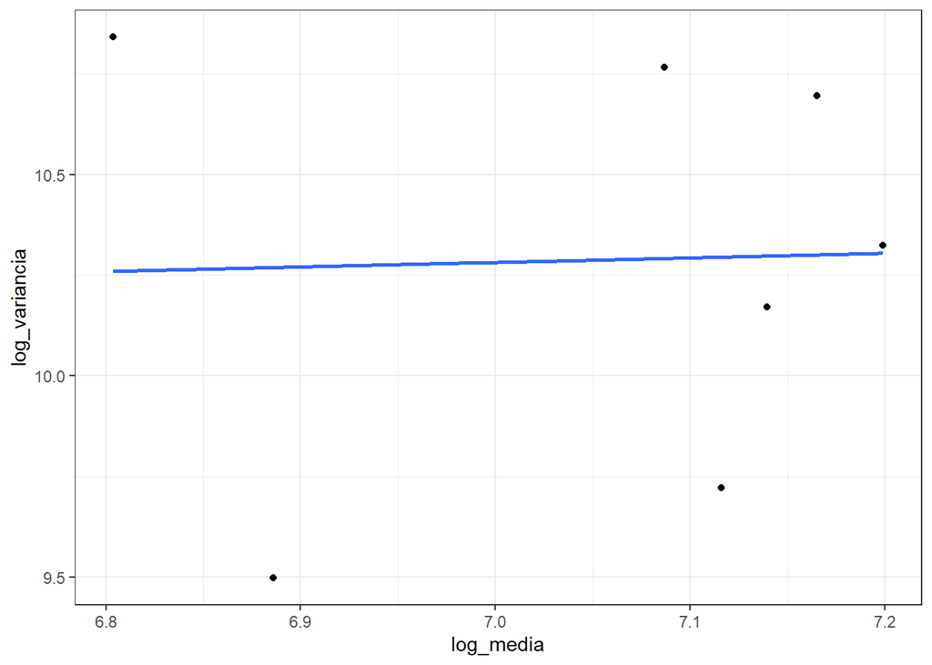

```r
# 1) Cálculo do log das variâncias e das médias por tratamentos
df_aux <- diagnostico |>
  group_by(trat) |>
  summarise(
    log_media = log(mean(y, na.rm = TRUE)),
    log_variancia = log(var(y, na.rm = TRUE)),
  )

df_aux |>
  ggplot(aes(x=log_media, y=log_variancia)) +
  geom_point() +
  geom_smooth(method = "lm", se=FALSE)
```

```r
# 2) Análise de regressão linear simples de log_variancia
# em função de log_media.
mod_reg <- lm( log_variancia ~ log_media,
               data = df_aux)
summary.lm(mod_reg)
```

```
##
## Call:
## lm(formula = log_variancia ~ log_media, data = df_aux)
##
## Residuals:
##        1        2        3        4        5        6        7
##  0.39517  0.01928 -0.57322 -0.12609  0.47490  0.58179 -0.77183
##
## Coefficients:
##             Estimate Std. Error t value Pr(>|t|)
## (Intercept)   9.4959    11.0162   0.862    0.428
## log_media     0.1123     1.5608   0.072    0.945
##
## Residual standard error: 0.5763 on 5 degrees of freedom
## Multiple R-squared:  0.001034,   Adjusted R-squared:  -0.1988
## F-statistic: 0.005177 on 1 and 5 DF,  p-value: 0.9454
```

```r
# 3) Transformação, se necessária:
b <- mod_reg$coefficients[2]
yt <- y^(1-b/2)
```

#### Transformação - Box - Cox

A transformação Box-Cox é uma das possíveis formas de contornar o problema de dados que não obedecem os pressupostos da análise de variância, como normalidade dos dados.

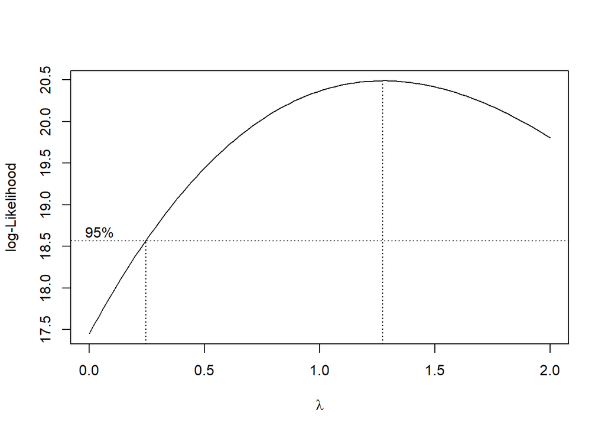

```r
boxcox(mod,seq(0,2,0.2))
```

+ se lambda não difere de 1: Dados são homocedásticos  
+ se lambda difere de 1 (Transformação:

$$\begin{cases}
yt = y^\lambda: \text{se lambda difere de 0} \\
yt = \log{y}: \text{se lambda não difere de 0}
\end{cases}$$

## A análise de variância

### Definição do modelo final

```r
modelo_final <- aov(y ~ trat)
anova(modelo_final)
```

```
## Analysis of Variance Table
##
## Response: y
##           Df Sum Sq Mean Sq F value  Pr(>F)
## trat       6 660112  110019   3.359 0.01763 *
## Residuals 21 687827   32754
## ---
## Signif. codes:  0 '***' 0.001 '**' 0.01 '*' 0.05 '.' 0.1 ' ' 1
```

### Cálculo do CV

$$CV =100
\frac{\sqrt{QM_{res}}}{\hat{m}}$$

```r
sqr <- deviance(modelo_final) # soma de quadrados dos resíduos
glr <- df.residual(modelo_final) # graus de liberdade dos resíduos
qmr <- sqr/glr # calculando o quadrado médio dos resíduos
media <- mean(y, na.rm = TRUE) # média geral do ensaio
100*sqrt(qmr)/media # cálculo do CV
```

```
## [1] 15.45124
```

### Procedimentos Para Comparações Múltiplas

Quando não se tem qualquer informação a priori sobre os tratamentos, sugere-se “comparações múltiplas”. Os testes mais comuns para Comparações Múltiplas são:

- Tukey;
- Duncan;
- Student Newman Keuls (SNK);
- t Student (LSD);

#### Teste de Tukey

Utilizando o Pacote agricolae

```r
HSD.test(modelo_final, "trat",
         alpha=0.05, group = TRUE,
         console = TRUE)
```

```
##
## Study: modelo_final ~ "trat"
##
## HSD Test for y
##
## Mean Square Error:  32753.68
##
## trat,  means
##
##          y      std r      se     Min     Max       Q25      Q50       Q75
## 1 1293.210 210.1515 4 90.4899 1067.90 1475.31 1137.3425 1314.815 1470.6825
## 2 1337.963 174.4775 4 90.4899 1172.84 1512.35 1195.9850 1333.330 1475.3075
## 3 1231.483 129.1384 4 90.4899 1111.11 1413.58 1166.6700 1200.620 1265.4325
## 4 1260.803 161.7050 4 90.4899 1043.21 1401.23 1186.7300 1299.385 1373.4575
## 5 1195.987 217.7411 4 90.4899  938.27 1450.62 1077.1625 1197.530 1316.3550
## 6  901.235 226.0735 4 90.4899  580.25 1111.11  858.0275  956.790  999.9975
## 7  978.395 115.4299 4 90.4899  851.85 1123.46  912.0375  969.135 1035.4925
##
## Alpha: 0.05 ; DF Error: 21
## Critical Value of Studentized Range: 4.597302
##
## Minimun Significant Difference: 416.0094
##
## Treatments with the same letter are not significantly different.
##
##          y groups
## 2 1337.963      a
## 1 1293.210     ab
## 4 1260.803     ab
## 3 1231.483     ab
## 5 1195.987     ab
## 7  978.395     ab
## 6  901.235      b
```

Utilizando o Pacote ExpDes.pt

```r
dic(trat,y,mcomp = "tukey", sigF = 0.05,
    sigT = 0.05)
```

```
## ------------------------------------------------------------------------
## Quadro da analise de variancia
## ------------------------------------------------------------------------
##            GL      SQ     QM    Fc    Pr>Fc
## Tratamento  6  660112 110019 3.359 0.017633
## Residuo    21  687827  32754
## Total      27 1347939
## ------------------------------------------------------------------------
## CV = 15.45 %
##
## ------------------------------------------------------------------------
## Teste de normalidade dos residuos ( Shapiro-Wilk )
## Valor-p:  0.3108865
## De acordo com o teste de Shapiro-Wilk a 5% de significancia, os residuos podem ser considerados normais.
## ------------------------------------------------------------------------
##
## ------------------------------------------------------------------------
## Teste de homogeneidade de variancia
## valor-p:  0.917768
## De acordo com o teste de bartlett a 5% de significancia, as variancias podem ser consideradas homogeneas.
## ------------------------------------------------------------------------
##
## Teste de Tukey
## ------------------------------------------------------------------------
## Grupos Tratamentos Medias
## a     2   1337.963
## ab    1   1293.21
## ab    4   1260.803
## ab    3   1231.483
## ab    5   1195.987
## ab    7   978.395
##  b    6   901.235
## ------------------------------------------------------------------------
```

#### Teste de Duncan

Utilizando o Pacote Agricolae

```r
duncan.test(modelo_final, "trat",
         alpha=0.05, group = TRUE,
         console = TRUE)
```

```
##
## Study: modelo_final ~ "trat"
##
## Duncan's new multiple range test
## for y
##
## Mean Square Error:  32753.68
##
## trat,  means
##
##          y      std r      se     Min     Max       Q25      Q50       Q75
## 1 1293.210 210.1515 4 90.4899 1067.90 1475.31 1137.3425 1314.815 1470.6825
## 2 1337.963 174.4775 4 90.4899 1172.84 1512.35 1195.9850 1333.330 1475.3075
## 3 1231.483 129.1384 4 90.4899 1111.11 1413.58 1166.6700 1200.620 1265.4325
## 4 1260.803 161.7050 4 90.4899 1043.21 1401.23 1186.7300 1299.385 1373.4575
## 5 1195.987 217.7411 4 90.4899  938.27 1450.62 1077.1625 1197.530 1316.3550
## 6  901.235 226.0735 4 90.4899  580.25 1111.11  858.0275  956.790  999.9975
## 7  978.395 115.4299 4 90.4899  851.85 1123.46  912.0375  969.135 1035.4925
##
## Alpha: 0.05 ; DF Error: 21
##
## Critical Range
##        2        3        4        5        6        7
## 266.1324 279.3991 287.8556 293.7814 298.1666 301.5269
##
## Means with the same letter are not significantly different.
##
##          y groups
## 2 1337.963      a
## 1 1293.210      a
## 4 1260.803     ab
## 3 1231.483     ab
## 5 1195.987     ab
## 7  978.395     bc
## 6  901.235      c
```

#### Teste de Student-Newman-Keuls

```r
SNK.test(modelo_final, "trat",
         alpha=0.05, group = TRUE,
         console = TRUE)
```

```
##
## Study: modelo_final ~ "trat"
##
## Student Newman Keuls Test
## for y
##
## Mean Square Error:  32753.68
##
## trat,  means
##
##          y      std r      se     Min     Max       Q25      Q50       Q75
## 1 1293.210 210.1515 4 90.4899 1067.90 1475.31 1137.3425 1314.815 1470.6825
## 2 1337.963 174.4775 4 90.4899 1172.84 1512.35 1195.9850 1333.330 1475.3075
## 3 1231.483 129.1384 4 90.4899 1111.11 1413.58 1166.6700 1200.620 1265.4325
## 4 1260.803 161.7050 4 90.4899 1043.21 1401.23 1186.7300 1299.385 1373.4575
## 5 1195.987 217.7411 4 90.4899  938.27 1450.62 1077.1625 1197.530 1316.3550
## 6  901.235 226.0735 4 90.4899  580.25 1111.11  858.0275  956.790  999.9975
## 7  978.395 115.4299 4 90.4899  851.85 1123.46  912.0375  969.135 1035.4925
##
## Alpha: 0.05 ; DF Error: 21
##
## Critical Range
##        2        3        4        5        6        7
## 266.1324 322.5625 356.7001 381.2335 400.3593 416.0094
##
## Means with the same letter are not significantly different.
##
##          y groups
## 2 1337.963      a
## 1 1293.210     ab
## 4 1260.803     ab
## 3 1231.483     ab
## 5 1195.987     ab
## 7  978.395     ab
## 6  901.235      b
```

#### Teste t-Student (LSD)

```r
LSD.test(modelo_final, "trat",
         alpha=0.05, group = TRUE,
         console = TRUE)
```

```
##
## Study: modelo_final ~ "trat"
##
## LSD t Test for y
##
## Mean Square Error:  32753.68
##
## trat,  means and individual ( 95 %) CI
##
##          y      std r      se      LCL      UCL     Min     Max       Q25
## 1 1293.210 210.1515 4 90.4899 1105.026 1481.394 1067.90 1475.31 1137.3425
## 2 1337.963 174.4775 4 90.4899 1149.778 1526.147 1172.84 1512.35 1195.9850
## 3 1231.483 129.1384 4 90.4899 1043.298 1419.667 1111.11 1413.58 1166.6700
## 4 1260.803 161.7050 4 90.4899 1072.618 1448.987 1043.21 1401.23 1186.7300
## 5 1195.987 217.7411 4 90.4899 1007.803 1384.172  938.27 1450.62 1077.1625
## 6  901.235 226.0735 4 90.4899  713.051 1089.419  580.25 1111.11  858.0275
## 7  978.395 115.4299 4 90.4899  790.211 1166.579  851.85 1123.46  912.0375
##        Q50       Q75
## 1 1314.815 1470.6825
## 2 1333.330 1475.3075
## 3 1200.620 1265.4325
## 4 1299.385 1373.4575
## 5 1197.530 1316.3550
## 6  956.790  999.9975
## 7  969.135 1035.4925
##
## Alpha: 0.05 ; DF Error: 21
## Critical Value of t: 2.079614
##
## least Significant Difference: 266.1324
##
## Treatments with the same letter are not significantly different.
##
##          y groups
## 2 1337.963      a
## 1 1293.210      a
## 4 1260.803      a
## 3 1231.483     ab
## 5 1195.987     ab
## 7  978.395     bc
## 6  901.235      c
```

### Gráfico de médias e letras

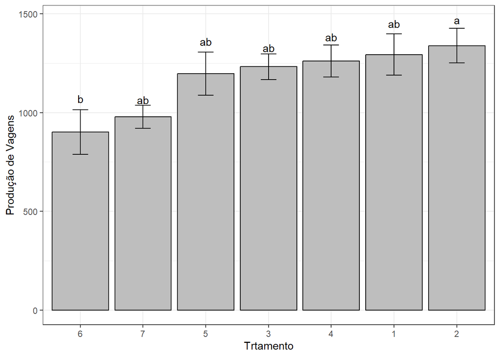

```r
tukey <- HSD.test(modelo_final, "trat",
         alpha=0.05, group = TRUE)
ntr <- tukey$parameters$ntr

diagnostico |>
  group_by(trat) |>
  summarise(
    media = mean(y),
    epm = sd(y)/sqrt(n())
  ) |>
  left_join(tukey$groups |> data.frame() |> add_column(
  trat = rownames(tukey$groups)),
  by = "trat") |>
  ungroup() |>
  mutate(
    trat = trat |> as_factor() |> fct_reorder(media)
  ) |>
  ggplot(aes(x=trat, y=y)) +
  geom_col(color="black", fill="gray") +   geom_errorbar(aes(
    ymax = y+epm, ymin = y-epm),
    width = 0.25) +
  geom_text(aes(label = groups,
                y = y+epm*1.5)) +
  labs(x="Trtamento", y="Produção de Vagens")
```